[figure not shown]

# Visualizing a nested data frame

A few data analytics ideas from [data-to-viz.com](https://github.com/holtzy/)

This page provides a few graphic suggestions to represent a nested dataset. A nested dataset means that we have a hierarchical organization in the data. The main group is divided in several subgroups and so on. This document consider the world population of 250 countries as an example. The world is divided in continent (group), continent are divided in regions (subgroup), and regions are divided in countries. In this tree structure, countries are considered as leaves: they are at the end of the branches.

Data come from wikipedia and formatted using these 2 pages. ([1](https://github.com/mledoze/countries), 2). A clean `.csv` file is available on [github](https://raw.githubusercontent.com/holtzy/data_to_viz/master/Example_dataset/11_SevCatOneNumNestedOneObsPerGroup.csv). It looks like that:

```r
# Libraries
library(tidyverse)
library(hrbrthemes)
library(kableExtra)
options(knitr.table.format = "html")

# Load dataset from github
data <- read.table("https://raw.githubusercontent.com/holtzy/data_to_viz/master/Example_dataset/11_SevCatOneNumNestedOneObsPerGroup.csv", header=T, sep=";")
data[ which(data$value==-1),"value"] <- 1
colnames(data) <- c("Continent", "Region", "Country", "Pop")
# show data
data %>% head(3) %>% kable() %>%
  kable_styling(bootstrap_options = "striped", full_width = F)
```

| Continent | Region | Country | Pop |
| --- | --- | --- | --- |
| Asia | Southern Asia | Afghanistan | 25500100 |
| Europe | Northern Europe | Åland Islands | 28502 |
| Europe | Southern Europe | Albania | 2821977 |

# Option 1: Lollipop

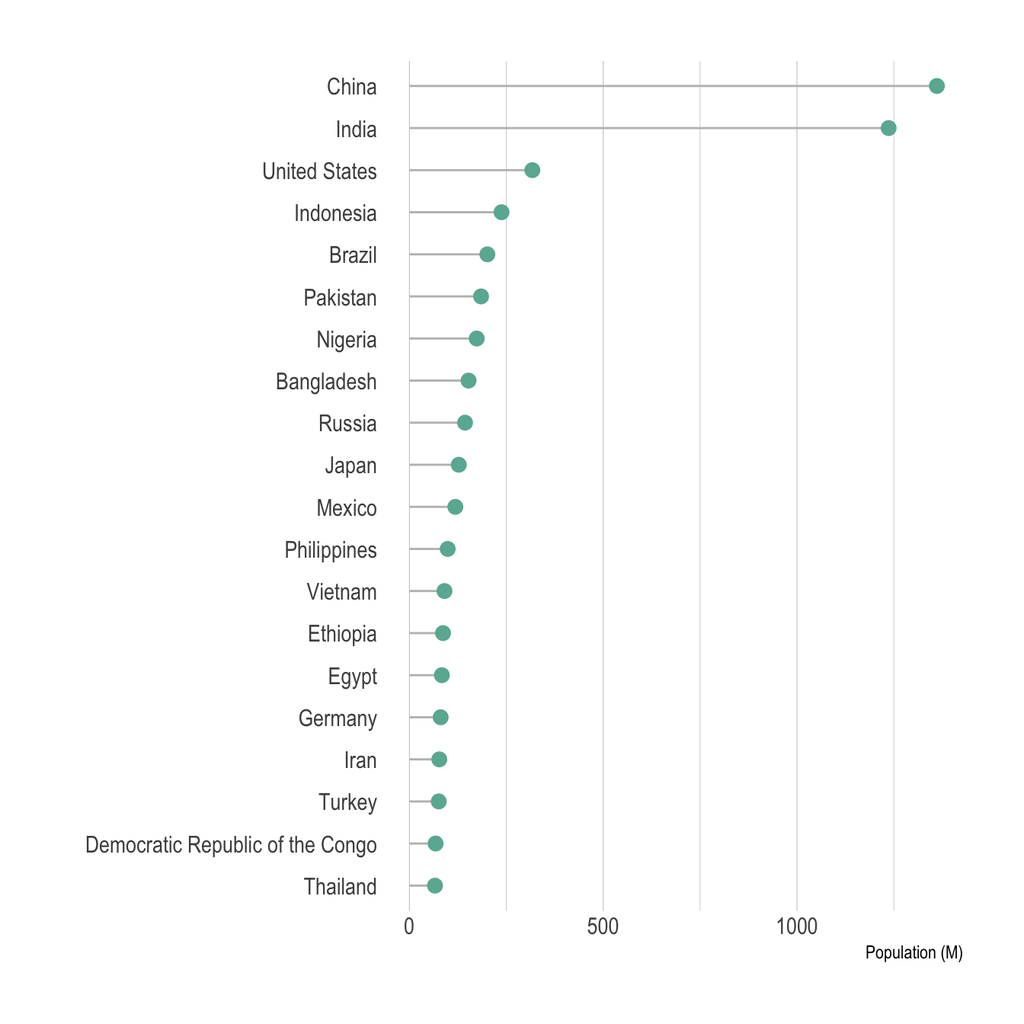

```r
data %>%
  filter(!is.na(Pop)) %>%
  arrange(Pop) %>%
  tail(20) %>%
  mutate(Country=factor(Country, Country)) %>%
  mutate(Pop=Pop/1000000) %>%
  ggplot( aes(x=Country, y=Pop) ) +
    geom_segment( aes(x=Country ,xend=Country, y=0, yend=Pop), color="grey") +
    geom_point(size=3, color="#69b3a2") +
    coord_flip() +
    theme_ipsum() +
    theme(
      panel.grid.minor.y = element_blank(),
      panel.grid.major.y = element_blank(),
      legend.position="none"
    ) +
    xlab("") +
    ylab("Population (M)")
```

# Treemap

A treemap represents each node of the hierarchical structure as a square. Each square area is proportionnal to its value: the population here.

```r
library(treemap)

p <- treemap(data,

            # data
            index=c("Continent", "Region", "Country"),
            vSize="Pop",
            type="index",

            # Main
            title="",
            palette="Dark2",

            # Borders:
            border.col=c("black", "grey", "grey"),
            border.lwds=c(1,0.5,0.1),

            # Labels
            fontsize.labels=c(0.7, 0.4, 0.3),
            fontcolor.labels=c("white", "white", "black"),
            fontface.labels=1,
            bg.labels=c("transparent"),
            align.labels=list( c("center", "center"), c("left", "top"), c("right", "bottom")),
            overlap.labels=0.5,
            inflate.labels=T

)
```

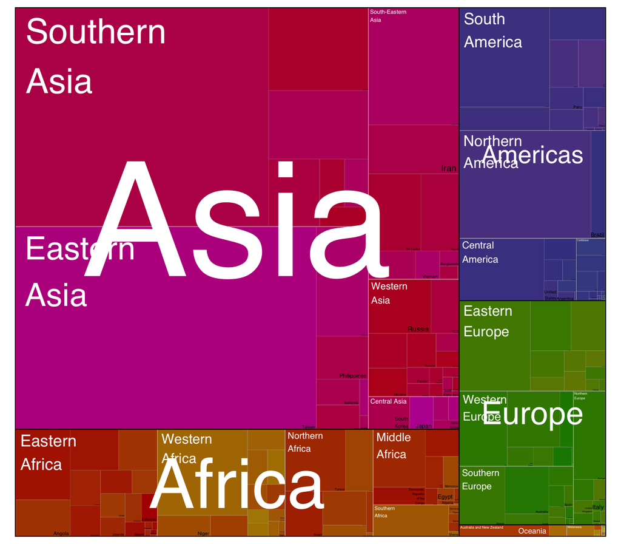

## Interactive

It is quite common to use an interactive version of the treemap:

```r
library(d3treeR)

d3tree2( p ,  rootname = "General" )
```

[interactive chart not shown]

# Circle packing

Circle packing follows the same idea than treemap, except that it uses circles instead of squares to represent each nodes. Because of that it uses space less efficiently. However groups are more obvious and the figure appear less cluttered.

```r
# Libraries
library(circlepackeR)


# Remove a few problematic lines
data <- data %>% filter(Continent!="") %>% droplevels()

# Change the format. This use the data.tree library. This library needs a column that looks like root/group/subgroup/..., so I build it
library(data.tree)
data$pathString <- paste("world", data$Continent, data$Region, data$Country, sep = "/")
population <- as.Node(data)

# You can custom the minimum and maximum value of the color range.
circlepackeR(population, size = "Pop", color_min = "hsl(56,80%,80%)", color_max = "hsl(341,30%,40%)")
```

[interactive chart not shown]

A work by [Yan Holtz](https://github.com/holtzy/) for data-to-viz.com